# Exploratoring the dataset

## Overview

The dataset contains information regarding multiple factors of red wine. Our main interest is to identify what factors influence the quality rate of red wine.

Dataset structure and overview:

```
##  [1] "X"                    "fixed.acidity"        "volatile.acidity"
##  [4] "citric.acid"          "residual.sugar"       "chlorides"
##  [7] "free.sulfur.dioxide"  "total.sulfur.dioxide" "density"
## [10] "pH"                   "sulphates"            "alcohol"
## [13] "quality"
```

```
##   X fixed.acidity volatile.acidity citric.acid residual.sugar chlorides
## 1 1           7.4             0.70        0.00            1.9     0.076
## 2 2           7.8             0.88        0.00            2.6     0.098
## 3 3           7.8             0.76        0.04            2.3     0.092
## 4 4          11.2             0.28        0.56            1.9     0.075
## 5 5           7.4             0.70        0.00            1.9     0.076
## 6 6           7.4             0.66        0.00            1.8     0.075
##   free.sulfur.dioxide total.sulfur.dioxide density   pH sulphates alcohol
## 1                  11                   34  0.9978 3.51      0.56     9.4
## 2                  25                   67  0.9968 3.20      0.68     9.8
## 3                  15                   54  0.9970 3.26      0.65     9.8
## 4                  17                   60  0.9980 3.16      0.58     9.8
## 5                  11                   34  0.9978 3.51      0.56     9.4
## 6                  13                   40  0.9978 3.51      0.56     9.4
##   quality
## 1       5
## 2       5
## 3       5
## 4       6
## 5       5
## 6       5
```

```
## 'data.frame':    1599 obs. of  13 variables:
##  $ X                   : int  1 2 3 4 5 6 7 8 9 10 ...
##  $ fixed.acidity       : num  7.4 7.8 7.8 11.2 7.4 7.4 7.9 7.3 7.8 7.5 ...
##  $ volatile.acidity    : num  0.7 0.88 0.76 0.28 0.7 0.66 0.6 0.65 0.58 0.5 ...
##  $ citric.acid         : num  0 0 0.04 0.56 0 0 0.06 0 0.02 0.36 ...
##  $ residual.sugar      : num  1.9 2.6 2.3 1.9 1.9 1.8 1.6 1.2 2 6.1 ...
##  $ chlorides           : num  0.076 0.098 0.092 0.075 0.076 0.075 0.069 0.065 0.073 0.071 ...
##  $ free.sulfur.dioxide : num  11 25 15 17 11 13 15 15 9 17 ...
##  $ total.sulfur.dioxide: num  34 67 54 60 34 40 59 21 18 102 ...
##  $ density             : num  0.998 0.997 0.997 0.998 0.998 ...
##  $ pH                  : num  3.51 3.2 3.26 3.16 3.51 3.51 3.3 3.39 3.36 3.35 ...
##  $ sulphates           : num  0.56 0.68 0.65 0.58 0.56 0.56 0.46 0.47 0.57 0.8 ...
##  $ alcohol             : num  9.4 9.8 9.8 9.8 9.4 9.4 9.4 10 9.5 10.5 ...
##  $ quality             : int  5 5 5 6 5 5 5 7 7 5 ...
```

Our dataset is consist of 1599 observations for 13 variables. The X variable is simply an index column. The remaining 12 variables are numerical data. The Quality variable is provided as integers and thus discrete.

And let's look at the summary for the 12 numerical variables.

```
##  fixed.acidity   volatile.acidity  citric.acid    residual.sugar
##  Min.   : 4.60   Min.   :0.1200   Min.   :0.000   Min.   : 0.900
##  1st Qu.: 7.10   1st Qu.:0.3900   1st Qu.:0.090   1st Qu.: 1.900
##  Median : 7.90   Median :0.5200   Median :0.260   Median : 2.200
##  Mean   : 8.32   Mean   :0.5278   Mean   :0.271   Mean   : 2.539
##  3rd Qu.: 9.20   3rd Qu.:0.6400   3rd Qu.:0.420   3rd Qu.: 2.600
##  Max.   :15.90   Max.   :1.5800   Max.   :1.000   Max.   :15.500
##    chlorides       free.sulfur.dioxide total.sulfur.dioxide
##  Min.   :0.01200   Min.   : 1.00       Min.   :  6.00
##  1st Qu.:0.07000   1st Qu.: 7.00       1st Qu.: 22.00
##  Median :0.07900   Median :14.00       Median : 38.00
##  Mean   :0.08747   Mean   :15.87       Mean   : 46.47
##  3rd Qu.:0.09000   3rd Qu.:21.00       3rd Qu.: 62.00
##  Max.   :0.61100   Max.   :72.00       Max.   :289.00
##     density             pH          sulphates         alcohol
##  Min.   :0.9901   Min.   :2.740   Min.   :0.3300   Min.   : 8.40
##  1st Qu.:0.9956   1st Qu.:3.210   1st Qu.:0.5500   1st Qu.: 9.50
##  Median :0.9968   Median :3.310   Median :0.6200   Median :10.20
##  Mean   :0.9967   Mean   :3.311   Mean   :0.6581   Mean   :10.42
##  3rd Qu.:0.9978   3rd Qu.:3.400   3rd Qu.:0.7300   3rd Qu.:11.10
##  Max.   :1.0037   Max.   :4.010   Max.   :2.0000   Max.   :14.90
##     quality
##  Min.   :3.000
##  1st Qu.:5.000
##  Median :6.000
##  Mean   :5.636
##  3rd Qu.:6.000
##  Max.   :8.000
```

The mean and variability is now shown descriptively and now I want to create a histogram plot for each variable so that I will be able to ovserve their distributions:

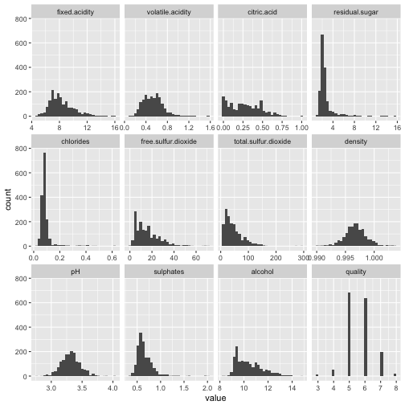

Here we have a big picture of how each variable distributes. Density and PH seems to be normaldistributed. Many of the variables seems to be having a normal distribution which skewed to right. Citric acid seems to be not normally distributed at all. I want to take a closer look at quality, residual.sugar and chlorides and will explain in detail in the following section.

## Univariate Analysis

Among all the variables, because in this project our target is to know what factors affect the wine quality rates, lets look closely at our independent variable, which is quality, as a first step:

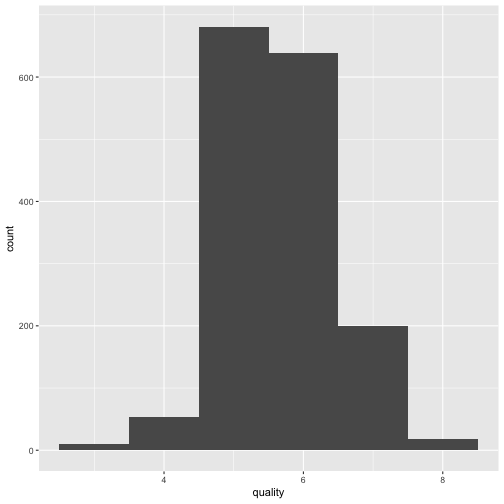

```
##    Min. 1st Qu.  Median    Mean 3rd Qu.    Max.
##   3.000   5.000   6.000   5.636   6.000   8.000
```

The quality rates spread from 3 to 8 and is overall normally distributed. The average quality rates centered at 5 and 6.

Among all the variables, the distributions of residual sugar and chlorides are extremely skewed to the right due to a few high value outliers.

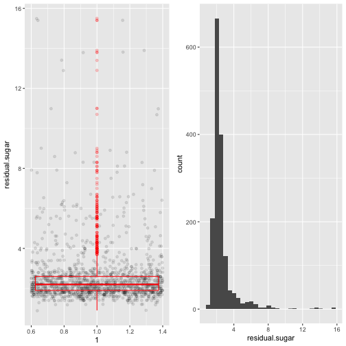

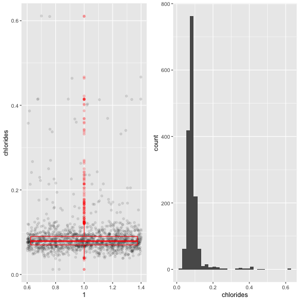

To better understand these two variables, I want to exclude the top 5% of the data for each variable and replot their histograms to see if the distributions make a better sense that way.

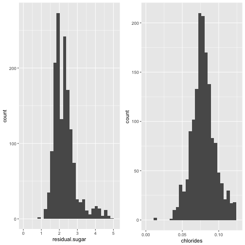

```
##    Min. 1st Qu.  Median    Mean 3rd Qu.    Max.
##   0.900   1.900   2.200   2.539   2.600  15.500
```

```
##    Min. 1st Qu.  Median    Mean 3rd Qu.    Max.
## 0.01200 0.07000 0.07900 0.08747 0.09000 0.61100
```

After modifying the data and removing outliers from residual sugar and chlorides data, both of the distributions tends to be normal.

## Bivariate Relationships

We can quickly visualize the relationship between each pair of variables and find their pearson product-moment correlation. The names along the x and y axis of the plot matrix below are as follows:

```
##  [1] "fixed.acidity"        "volatile.acidity"     "citric.acid"
##  [4] "residual.sugar"       "chlorides"            "free.sulfur.dioxide"
##  [7] "total.sulfur.dioxide" "density"              "pH"
## [10] "sulphates"            "alcohol"              "quality"
```

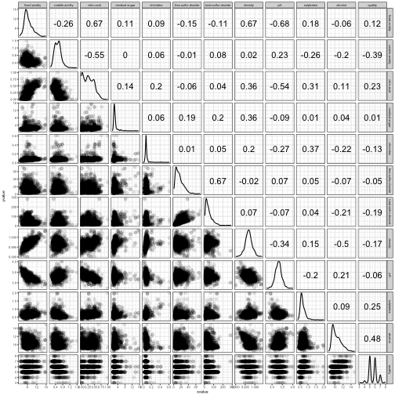

As our independent variable is quality, we find the positive correlation coefficients with quality are:

- alcohol:quality = 0.48
- sulphates:quality = 0.25
- citric.acid:quality = 0.23
- fixed.acidity:quality = 0.12
- residual.sugar:quality = 0.01

These factors positively contribute to wine quality rate. Suprisingly alcohol does have the highest correlation with quality, at least by only looking at the bivariate relationship. I created a plot to visualize this relationship:

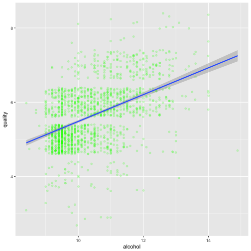

The second high coefficient here is sulphates:

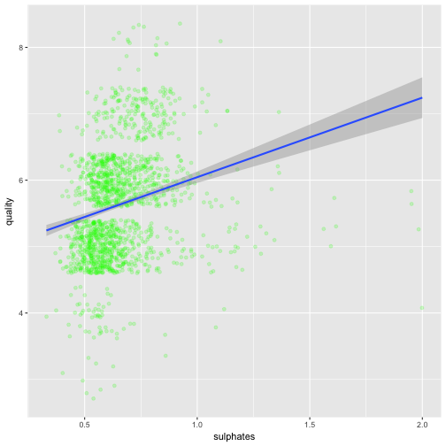

The following factors have negative corrlation coefficients with quality:

- volatile.acidity:quality = -0.39
- total.sulfur.dioxide:quality = -0.19
- density:quality = -0.17
- chlorides:quality = -0.13
- PH:quality =-0.06
- free.sulfur.dioxide:quality = -0.05

Volatile acids has big negative impact on red wine quality. Total sulfur dioxide, density and chlorides are also negatively correlated with quality.

total.sulfur.dioxide vs quality:

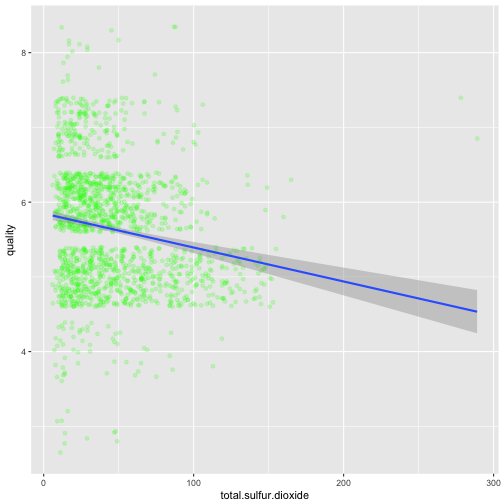

volatile acidity vs quality:

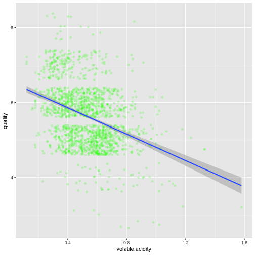

Inter correlation between dependent variables may affect our analysis in the next section, lets also take a look at those variables with the highest (positive or negative) correlations:

- fixed.acidity:pH = -0.68
- fixed.acidity:citirc.acid = 0.67
- fixed.acidity:density = 0.67
- free.sulfur.dioxide:total.sulfur.dioxide = 0.67
- volatile.acidity:citirc.acid = -0.55
- citric.acid:pH = -0.54
- density:alcohol = -0.50

Some plots for these highly correlated factors:

fixed.acidity & pH:

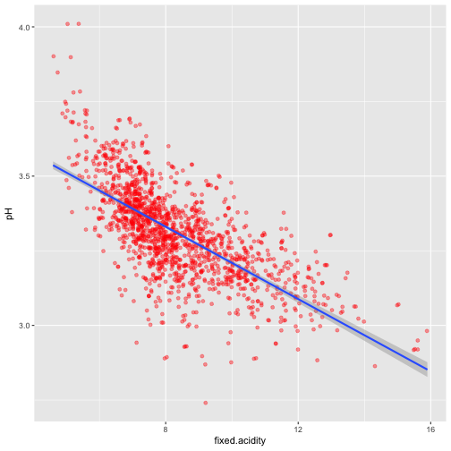

Fixed acidity and pH are negatively correlated.

density & alcohol

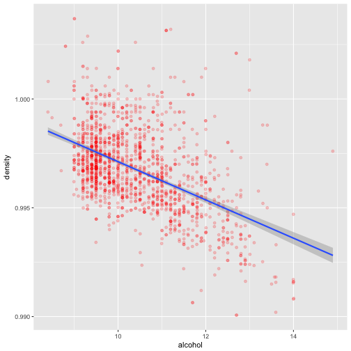

Density tends to increase with as alcohol decreases.

fixed acidity & density:

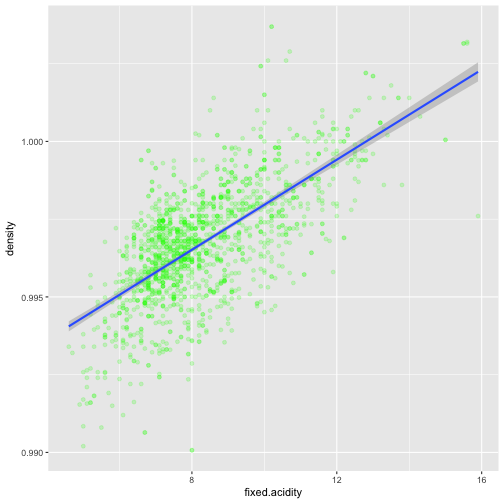

On the other hand fixed acidity increases as density increases.

I want to know how different quality rated red wine distribute over the alcohol factor, which has the highest positive correlation to quality as discussed before. Here is the density plot illustrates exactly what I am interested in:

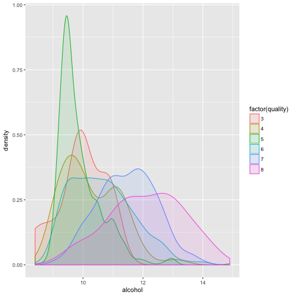

This plot does reflect that distributions for higher quality rated red wine (with score 7 or 8) does have their center shift to right on the graph. They tends to have more alcohol. But at the same time, the average quality 5 has its center on the most left. This indicate that lower alcohol does not necessarily suggests low quality.

Here are some summary statistics for alcohol and sulphates at each quality level, which I found relevant:

```
## factor(wine$quality): 3
##    Min. 1st Qu.  Median    Mean 3rd Qu.    Max.
##   8.400   9.725   9.925   9.955  10.575  11.000
## --------------------------------------------------------
## factor(wine$quality): 4
##    Min. 1st Qu.  Median    Mean 3rd Qu.    Max.
##    9.00    9.60   10.00   10.27   11.00   13.10
## --------------------------------------------------------
## factor(wine$quality): 5
##    Min. 1st Qu.  Median    Mean 3rd Qu.    Max.
##     8.5     9.4     9.7     9.9    10.2    14.9
## --------------------------------------------------------
## factor(wine$quality): 6
##    Min. 1st Qu.  Median    Mean 3rd Qu.    Max.
##    8.40    9.80   10.50   10.63   11.30   14.00
## --------------------------------------------------------
## factor(wine$quality): 7
##    Min. 1st Qu.  Median    Mean 3rd Qu.    Max.
##    9.20   10.80   11.50   11.47   12.10   14.00
## --------------------------------------------------------
## factor(wine$quality): 8
##    Min. 1st Qu.  Median    Mean 3rd Qu.    Max.
##    9.80   11.32   12.15   12.09   12.88   14.00
```

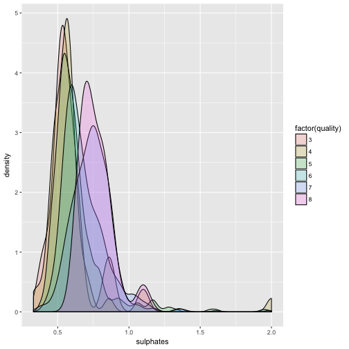

It looks like sulphate content is quite important for red wine quality, particularly for the highest quality levels including quality 7 and 8.

And here are the summary statistics for sulphates at each quality level, along with the plot:

```
## $`3`
##    Min. 1st Qu.  Median    Mean 3rd Qu.    Max.
##  0.4000  0.5125  0.5450  0.5700  0.6150  0.8600
##
## $`4`
##    Min. 1st Qu.  Median    Mean 3rd Qu.    Max.
##  0.3300  0.4900  0.5600  0.5964  0.6000  2.0000
##
## $`5`
##    Min. 1st Qu.  Median    Mean 3rd Qu.    Max.
##   0.370   0.530   0.580   0.621   0.660   1.980
##
## $`6`
##    Min. 1st Qu.  Median    Mean 3rd Qu.    Max.
##  0.4000  0.5800  0.6400  0.6753  0.7500  1.9500
##
## $`7`
##    Min. 1st Qu.  Median    Mean 3rd Qu.    Max.
##  0.3900  0.6500  0.7400  0.7413  0.8300  1.3600
##
## $`8`
##    Min. 1st Qu.  Median    Mean 3rd Qu.    Max.
##  0.6300  0.6900  0.7400  0.7678  0.8200  1.1000
```

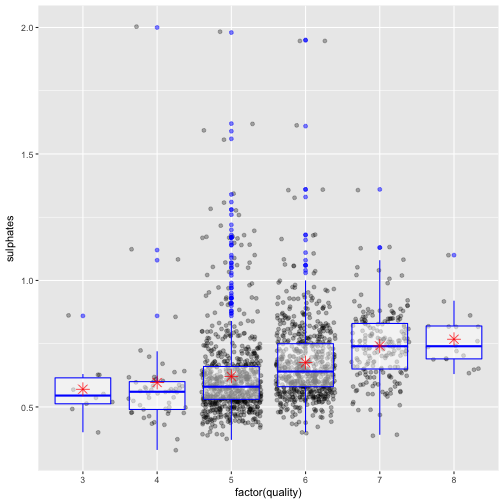

## Multivariate Relationships

Frome the last section, I found out that alcohol, sulphates and volatile acidity have crutial impact on red wine quality. I want to create two plots to visualize the relationship between these factors:

Volatile acidity, alcohol and quality:

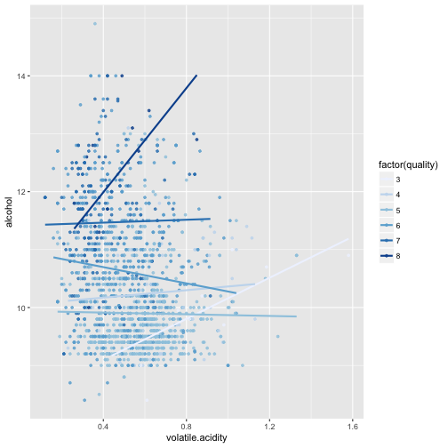

Sulphates, alcohol and quality:

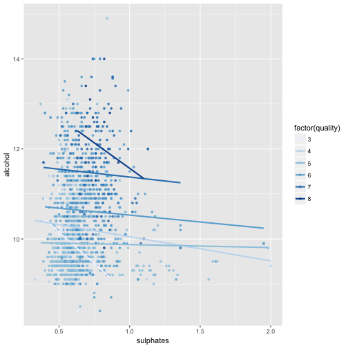

Let's only look at how quality relates to alcohol and sulphate by creating a contour plot:

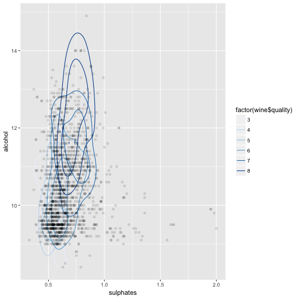

The high quality clusters (especially 7 and 8) tend to locate on the top right corner of the plot while the lower quality clusters tend to locate and the bottom left of the plot. It tells that higher sulphate and higher alcohol makes better quality red wine overall.

To be more straight forward, let's add the density graphs of alcohol and sulphate from the previous section to the multivariable chart:

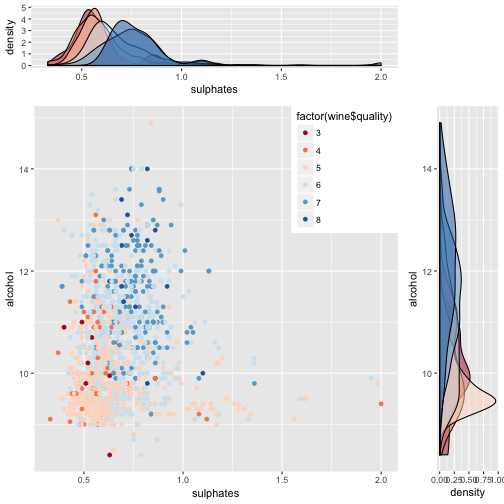

This plot combined of both multivariable and bivariable plot gives a more straightforward visualization for the positive relationship between sulphate and quality as well as alcohol and quality.

### Multivariable Analysis Summary:

From the scatter graph I feel that sulphates and alcohol have the most obvious influence on wine quality, especially for high quality wines. It is obvious that the high quality wines concentrate at the top right corner of the scatter plot. Based on this I combined hte scatter plot and the density plot for corresponding variable on each axis to show that both factors have positive impact on red wine quality.

# Final Plots

In this section, I want to summarize the analysis above and give a few crutial plots which helped better understanding the dataset.

### Plot 1

First of all I looked at the distribution of our independent factor quality

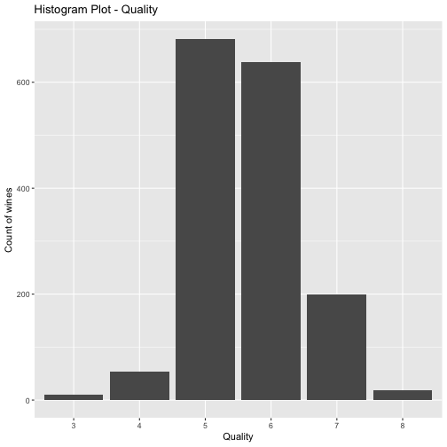

The histogram gives descrete wine quality range from 3-8, which concentrate at 5 and 6.

### Plot 2

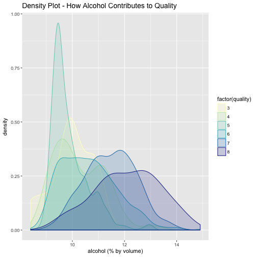

From this plot we can tell that higher quality wine (7 and 8) does tend to have higher alcohol, as the distrubutions tend to concentrate on the right side of the graph. However we also need to notice that the lower alcohol does not necessary represent lower quality as the most left distribution showing on the graph is actually that for quality 5, which is an average quality.

Here are the summary statistics for alcohol content at each quality level:

```
## wine$quality: 3
##    Min. 1st Qu.  Median    Mean 3rd Qu.    Max.
##   8.400   9.725   9.925   9.955  10.575  11.000
## --------------------------------------------------------
## wine$quality: 4
##    Min. 1st Qu.  Median    Mean 3rd Qu.    Max.
##    9.00    9.60   10.00   10.27   11.00   13.10
## --------------------------------------------------------
## wine$quality: 5
##    Min. 1st Qu.  Median    Mean 3rd Qu.    Max.
##     8.5     9.4     9.7     9.9    10.2    14.9
## --------------------------------------------------------
## wine$quality: 6
##    Min. 1st Qu.  Median    Mean 3rd Qu.    Max.
##    8.40    9.80   10.50   10.63   11.30   14.00
## --------------------------------------------------------
## wine$quality: 7
##    Min. 1st Qu.  Median    Mean 3rd Qu.    Max.
##    9.20   10.80   11.50   11.47   12.10   14.00
## --------------------------------------------------------
## wine$quality: 8
##    Min. 1st Qu.  Median    Mean 3rd Qu.    Max.
##    9.80   11.32   12.15   12.09   12.88   14.00
```

Similarily I looked at summary statistics for a few other factors and realize that sulphate has a relatively obvious impact on high quality wine:

```
## wine$quality: 3
##    Min. 1st Qu.  Median    Mean 3rd Qu.    Max.
##  0.4000  0.5125  0.5450  0.5700  0.6150  0.8600
## --------------------------------------------------------
## wine$quality: 4
##    Min. 1st Qu.  Median    Mean 3rd Qu.    Max.
##  0.3300  0.4900  0.5600  0.5964  0.6000  2.0000
## --------------------------------------------------------
## wine$quality: 5
##    Min. 1st Qu.  Median    Mean 3rd Qu.    Max.
##   0.370   0.530   0.580   0.621   0.660   1.980
## --------------------------------------------------------
## wine$quality: 6
##    Min. 1st Qu.  Median    Mean 3rd Qu.    Max.
##  0.4000  0.5800  0.6400  0.6753  0.7500  1.9500
## --------------------------------------------------------
## wine$quality: 7
##    Min. 1st Qu.  Median    Mean 3rd Qu.    Max.
##  0.3900  0.6500  0.7400  0.7413  0.8300  1.3600
## --------------------------------------------------------
## wine$quality: 8
##    Min. 1st Qu.  Median    Mean 3rd Qu.    Max.
##  0.6300  0.6900  0.7400  0.7678  0.8200  1.1000
```

### Plot 3

In the last section I wanted to show the relationship beteween quality, alcohol and sulphate on the same plot. So I created a scatter plot which summarize how both facotrs contribute to quality. At the same time, I have the density plot for each factor on the side of the plot so that we can understand the graph better:

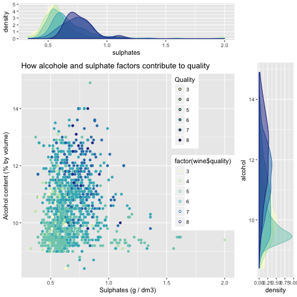

Here I combined the scatter plot with two density plots of the corresponding variables. As the density plots shows a positive relationship between each variable (sulphate and alcohol) and quality, the scatter plot also gives a straightforward visualization of how quality level increases from the bottom left corner to the top right corner (yellow to green to blue).

# Reflection

The red wine data set contains information of 12 variables for 1599 entries. The objective to explore this data set is to explore how different factors contribute to red wine quality. So first of all I plotted the distribution of quality and observed that it ranges from 3 to 8 while concentrate at average of 5 and 6. Then I started with looking at each of the other variable individually and understanding their features and distributions. I found that most of the data follows normal distribution. I struggled at first to understand the distributions of residual sugar and chlorides because both are extremely skewed to the right. And then I realize this is due to a few high value outliers. Their distributions look normal after removing outliers.

At the same time, I also observed that sulphate variable also has a positive contribution to red wine quality, especially for higher quality red wine. Considering the fact that both alcohole and sulphate are positively correlated with quality, I created a scatter plot along with the density plot of each variable to visualize this relationship.

We have successfully identified a few key factors that influence red wine quality in this analysis and successfully created plots to visualize these relations. There are still some ways to improve our analysis though. Overall, 1599 entries do not create a very big data set. A good way to improve our analysis is to collect more entries and include more information in the data set (for example, instead of using data starting from 2009, choose an ealier date). Other than that we can categorize the wine quality in a more specific rating. Currently we have 3 to 8 as the range, say what if we keep the integer rating but have 30 to 80, then the whole distribution will be more specific and we can better analyze the relation between other variables and quality variable.

## Reference

https://www.rstudio.com/wp-content/uploads/2015/03/ggplot2-cheatsheet.pdf [https://www.nceas.ucsb.edu/~frazier/RSpatialGuides/colorPaletteCheatsheet.pdf](https://www.nceas.ucsb.edu/%7Efrazier/RSpatialGuides/colorPaletteCheatsheet.pdf)